# Dynamic Mode Decomposition as a Linear Model for Spatio-Temporal Systems

Jeremy Roberts

December 1, 2019

# Introduction

This notebook includes the basic analysis shown in the final report. The report includes the necessary theory (equations, etc.), while this notebook puts the code into action.

# Load Data

First, load the maximum temperature data for July of 1993:

```r
library("dplyr")
library("STRbook")
data("NOAA_df_1990", package = "STRbook")
df <- filter(NOAA_df_1990, year == 1993, month == 7, proc == "Tmax")
```

Now, we need to clean up the data to include only those stations that have measurements for each day of the month. This greatly simplifies the DMD analysis, which is based on a dense [space, time] snapshot matrix.

There are 31 days in July, so search for all those station id’s that have 31 measurements and filter the data to include only those.

```r
keep <- c()
for (station in unique(df$id)) {
    if (length(filter(df, id == station)$julian) == 31) {
        keep <- append(keep, station)
    }
}
df <- filter(df, id %in% keep)
```

```r
df <- mutate(df, t=df$julian-min(df$julian))
```

Finally, to clean things up a bit, keep only `t`, `id` (the station number), `z` (the maximum temperature), `lat` (latitude), and `lon` (longitude):

```r
df <- subset(df, select=c(t, id, z, lat, lon))
head(df)
```

```
##   t   id  z   lat       lon
## 1 0 3804 82 39.35 -81.43333
## 2 1 3804 84 39.35 -81.43333
## 3 2 3804 88 39.35 -81.43333
## 4 3 3804 90 39.35 -81.43333
## 5 4 3804 92 39.35 -81.43333
## 6 5 3804 91 39.35 -81.43333
```

# Construct Snapshot Matrix

DMD is applied to a matrix $\mathbf{Z} \in \mathbb{R}^{m,n}$, or

```r
num_locs <- length(unique(df$id))
num_time <- length(df$id)/num_locs
Z <- t(matrix(as.numeric(df$z), num_time, num_locs, byrow = FALSE))
```

One way to view this data is by treating the elements of $\mathbf{Z}$ as pixels of an image (or a “heatmap”). Here, the temperature is shown on a 2-D grid of location (an arbirary index for each weather station) and day (in July):

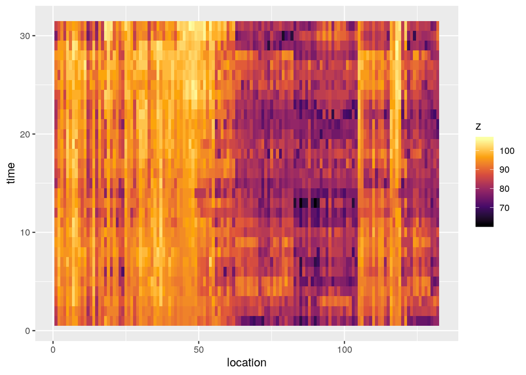

```r
library(ggplot2)
heat <- expand.grid(time = 1:num_time, location = 1:num_locs)
heat$z <- df$z
ggplot(heat, aes(location, time, fill = z)) + geom_tile() + scale_fill_viridis_c(option = "inferno")
```

```r
ggsave("snapshots.pdf")
```

# A DMD-Generated Basis for Statistical Linear Modeling: The Basic Approach

Given $\mathbf{Z}$, $\mathbf{Z}_- = \mathbf{Z}_{:,1:n-1}$, and $\mathbf{Z}_+ = \mathbf{Z}_{:, 2:n}$, the DMD algorithm employs the SVD to compute a rank-$r$ operator $\mathbf{A}_r$ that approximately satisfies $\mathbf{Z}_+ = \mathbf{A}_r\mathbf{Z}_-$. The eigenvectors $\boldsymbol{\phi}_i$ of $\mathbf{A}_r$ are the DMD “modes”, while the corresponding eigenvalues $\lambda_i$ yield the DMD frequencies $\omega_i = \log \lambda_i / \Delta_t$ for observations separated by a fixed $\Delta_t$ in time.

To support modeling of $\mathbf{z}(t)$ given the observed data, construction and use of a linear model based on `lm` requires a few steps:

1. Generate the DMD modes $\boldsymbol{\phi}_i$ and frequences $\omega_i$ given known observations and times.
2. Construct spatio-temporal DMD basis vectors $\boldsymbol{\psi}_i$ using the same observations and times.
3. Use `lm` to fit the model $\mathbf{z} \sim \mathcal{N}(\boldsymbol{\Psi}\boldsymbol{\beta}, \sigma^2\mathbf{I})$, where the DMD basis vectors are the covariates. This requires that a dataframe be generated with columns for each of those basis vectors.
4. Predictions should be made with `lm` for possibly different times than were used in the original fitting. In other words, the basis vectors may need to be reconstructed at new times with which a new dataframe is constructed.

# Inspecting DMD Modes

With the helper functions in place, it is useful to examine what goes into a DMD basis. Here, the full SVD and the optimally truncated SVD are computed to show where the “optimal” criterion sits for this data:

```r
source("dmd.R")
library(latex2exp)
pdf("singular_values.pdf",width=5,height=4)
svd_f <- compute_svd(Z, rank=-1)
svd_t <- compute_svd(Z, rank=0)
plot(svd_f$d, log="y", col="black",  xlab="", ylab="")
title(xlab=TeX('$i$'), ylab=TeX('$\\sigma_i$'))
r <- length(svd_t$d)
text(x=12, y=1.1*svd_t$d[r], labels = sprintf("optimal rank is %i", r), pos = 3., adj=c(0,0), col="red")
points(svd_t$d, col="red", pch=18)
dev.off()
```

The optimal rank is 7.

With this rank, compute the DMD modes and amplitudes. Here, just four modes are kept due to elimination of complex conjugates. These are normalized to 1 and shown as a function of station latitude. The first mode captures the anticipated dependence on latitude, i.e., with increasing latitude, the temperature should drop off. The specific “sign” of $\boldsymbol{\phi}_1$ is coincidentally in the right direction, but its the negative correlation that is important. The other modes are far harder to interpret.

```r
dmd <- compute_dmd(Z, rank=0)
tmp <- sort(filter(df, t==1)$lat, index.return=TRUE)
ix <- tmp$ix
lats <- tmp$x
pdf("dmd_modes.pdf")
par(mfrow=c(2, 2))
for (r in 1:4)
{
  y <-  Re(dmd$Phi[ix,r])
  y <- y / sqrt(sum(y^2))
  plot(lats, y, type="o", xlab="", ylab="")
  title(xlab="latitude (deg.)", ylab=TeX(sprintf("$\\phi_{%i}$", r)))
}
dev.off()
```

# Reconstructing The Original Data

```r
require(gridExtra)

models = list()
# Make DMD models and predictions
for (r in c(5, 7, -1)) {
    tmp <- lm_with_dmd(df, rank = r, keep_pairs = 2)
    tmp$pred <- predict_with_dmd(df, tmp$model, tmp$dmd)
    tmp$desc <- sprintf("DMD, rank=%i", tmp$dmd$rank)
    models[[length(models) + 1]] <- tmp
}
for (i in 1:3) {
    desc <- "z ~ (t+lat+lon)"
    if (i > 1) {
        desc <- sprintf("z ~ (t+lat+lon)^%i", i)
    }
    tmp <- list(model = lm(formula(desc), data = df))
    tmp$pred <- predict(tmp$model, interval = "prediction")
    tmp$desc <- desc
    models[[length(models) + 1]] <- tmp
}

# Given data, the model, and the prediction, make a plot of the prediction,
# make a plot of the prediction error, and compute a few key quantities.
p = list()
for (i in 1:length(models)) {
    m <- models[[i]]

    heat <- expand.grid(time = 1:num_time, location = 1:num_locs)
    heat$z <- m$pred[, 1]
    p[[length(p) + 1]] <- ggplot(heat, aes(location, time, fill = z)) + geom_tile() +
        theme_void() + labs(title = m$desc) + scale_fill_continuous(limits = c(60,
        110), type = "viridis", option = "inferno")

    aic <- AIC(m$model)
    desc <- sprintf("AIC = %.2f", aic)
    heat$error <- m$pred[, 1] - df$z
    print(sprintf("%.2f %.2f", max(heat$error), min(heat$error)))

    p[[length(p) + 1]] <- ggplot(heat, aes(location, time, fill = error)) +
        geom_tile() + scale_fill_distiller(palette = "Spectral", limits = c(-25,
        25)) + theme_void() + labs(title = desc)

    p[[length(p) + 1]] <- ggplot(filter(cbind(df, m$pred), id == 14943), aes(t,
        z)) + geom_point() + geom_line(aes(y = fit), color = "blue") + geom_line(aes(y = upr),
        color = "red", linetype = "dashed") + geom_line(aes(y = lwr), color = "red",
        linetype = "dashed")
}
```

```
## [1] "23.03 -13.82"
## [1] "22.73 -13.26"
## [1] "19.27 -16.61"
## [1] "21.76 -16.94"
## [1] "20.37 -14.01"
## [1] "20.38 -14.05"
```

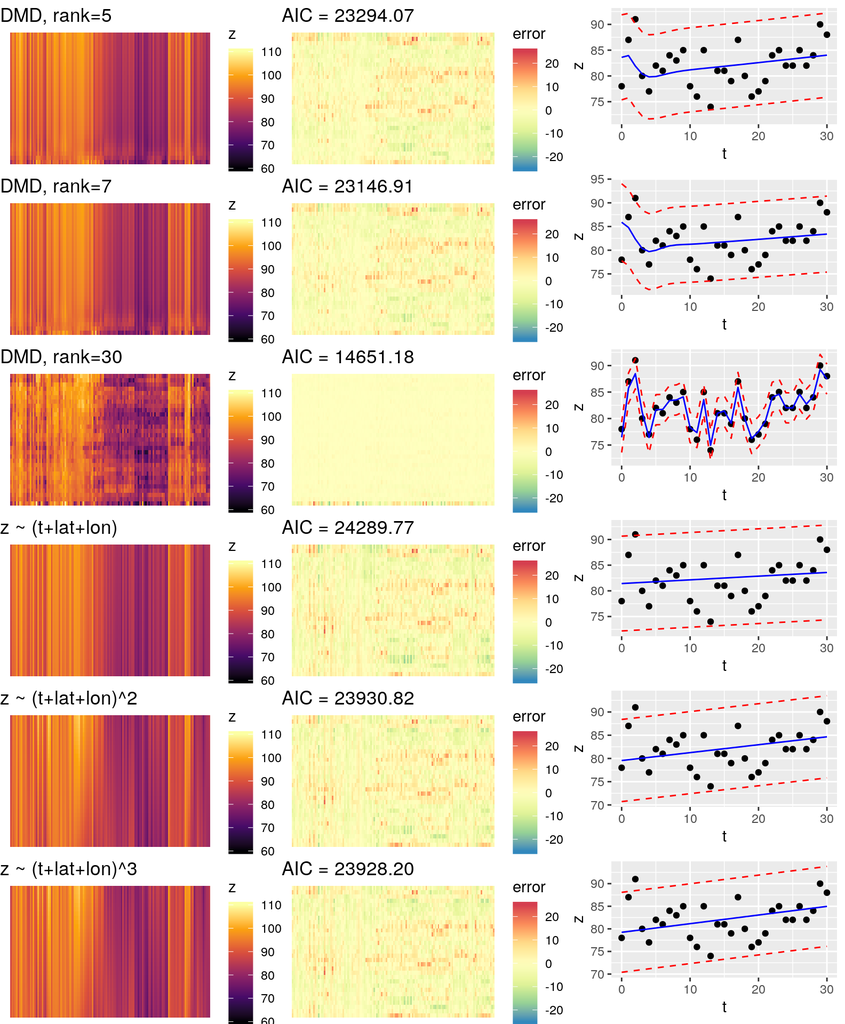

```r
q <- grid.arrange(grobs = p, ncol = 3)
```

```r
ggsave("model_comparison.png", q, dpi = 600, width = 12, height = 12, units = "in")
ggsave("model_comparison.pdf", q, dpi = 600, width = 12, height = 12, units = "in")
```

From these results, it appears the DMD-based models lead to lower AIC values than the simple polynomial models. Moreover, the DMD model based on the full SVD yields the lowest AIC value despite having the largest number of parameters to estimate. Hence, let’s investigate the impact of DMD rank on AIC. As noted, the “optimal” rank is based on an optimally truncated SVD that is itself based on statistical considerations. Here, AIC is computed for DMD as a function of rank. Note, complex-conjugate pairs are not reduced to one basis vector this time, though `lm` does in all cases eliminate the singularities.

```r
aic <- rep(0, 31)
aic2 <- rep(0, 31)
ranks <- rep(0, 31)
pdf("dmd_aic.pdf",width=5,height=3.5)
for (r in 1:31){
  m <- lm_with_dmd(df, rank=r, keep_pairs=0)
  aic[r] <- AIC(m$model)
  ranks[r] <- r-sum(is.na(m$model$coefficients))
  m <- lm_with_dmd(df, rank=r, keep_pairs=2)
  aic2[r] <- AIC(m$model)
}
plot(1:31, aic, type="b", pch=19, col="black", xlab="DMD rank", ylab="AIC", ylim=c(min(aic,aic2), max(aic, aic2)))
lines(1:31, aic2, pch=18, col="red", type="b", lty=2)
legend(1, 30000, legend=c("eliminate", "keep"),  col=c("black", "red"), lty=1:2, cex=0.8, pch=c(19,18))
dev.off()
```

The results indicate that the AIC generally decreases by a small amount as the number of modes include increases, with notable deviations between 20 and 26. Recall that the optimal SVD was 7, for which 4 DMD modes are retained (3 complex pairs reduced to 3 modes).

Because AIC is itself a statistic, a more careful comparison would estimate confidence intervals for AIC. However, because the DMD basis requires multiple steps to construct and requires a constant space-time grid, handling of resampled data would be a major challenge.

```r
for (i in 1:6) {
    print(summary(models[[i]]$model))
}
```

```
##
## Call:
## lm(formula = z ~ . - t - 1, data = df)
##
## Residuals:
##      Min       1Q   Median       3Q      Max
## -23.0335  -2.3076   0.2389   2.7100  13.8159
##
## Coefficients:
##         Estimate Std. Error   t value Pr(>|t|)
## Psi.1 -361685.32     270.94 -1334.950  < 2e-16 ***
## Psi.2     249.79      21.06    11.858  < 2e-16 ***
## Psi.3     812.92      66.37    12.248  < 2e-16 ***
## Psi.4      51.27      10.11     5.072  4.1e-07 ***
## Psi.5    -376.55      39.38    -9.561  < 2e-16 ***
## ---
## Signif. codes:  0 '***' 0.001 '**' 0.01 '*' 0.05 '.' 0.1 ' ' 1
##
## Residual standard error: 4.164 on 4087 degrees of freedom
## Multiple R-squared:  0.9978, Adjusted R-squared:  0.9978
## F-statistic: 3.72e+05 on 5 and 4087 DF,  p-value: < 2.2e-16
##
##
## Call:
## lm(formula = z ~ . - t - 1, data = df)
##
## Residuals:
##      Min       1Q   Median       3Q      Max
## -22.7291  -2.3057   0.1631   2.6608  13.2565
##
## Coefficients:
##         Estimate Std. Error  t value Pr(>|t|)
## Psi.1 361776.505    266.673 1356.628  < 2e-16 ***
## Psi.2   -302.225     54.645   -5.531 3.39e-08 ***
## Psi.3   -387.150     25.120  -15.412  < 2e-16 ***
## Psi.4    -83.390     33.198   -2.512   0.0120 *
## Psi.5    407.236     24.631   16.534  < 2e-16 ***
## Psi.6     -8.409      3.350   -2.510   0.0121 *
## Psi.7   -193.663     20.976   -9.233  < 2e-16 ***
## ---
```

[output cut: 107 more lines]

```
##               Estimate Std. Error t value Pr(>|t|)
## (Intercept) 80.2576337 21.7673336   3.687  0.00023 ***
## t            1.4167906  1.2463939   1.137  0.25573
## lat          1.0780202  0.5655475   1.906  0.05670 .
## lon         -0.6285183  0.2428244  -2.588  0.00968 **
## t:lat       -0.0884335  0.0323832  -2.731  0.00634 **
## t:lon        0.0067020  0.0139041   0.482  0.62982
## lat:lon      0.0262661  0.0063061   4.165 3.17e-05 ***
## t:lat:lon   -0.0007757  0.0003611  -2.148  0.03175 *
## ---
## Signif. codes:  0 '***' 0.001 '**' 0.01 '*' 0.05 '.' 0.1 ' ' 1
##
## Residual standard error: 4.498 on 4084 degrees of freedom
## Multiple R-squared:  0.6656, Adjusted R-squared:  0.665
## F-statistic:  1161 on 7 and 4084 DF,  p-value: < 2.2e-16
```

# Making Predictions

Here, essentially the same analysis is performed, but models are fitted using only the first 28 days of data.

```r
require(gridExtra)

df_partial <- filter(df, t < 28)

models2 = list()
# Make DMD models and predictions
for (r in c(5, 7, -1)) {
    tmp <- lm_with_dmd(df_partial, rank = r, keep_pairs = 2)
    tmp$pred <- predict_with_dmd(df, tmp$model, tmp$dmd)
    tmp$desc <- sprintf("DMD, rank=%i", tmp$dmd$rank)
    models2[[length(models2) + 1]] <- tmp
}
for (i in 1:3) {
    desc <- "z ~ (t+lat+lon)"
    if (i > 1) {
        desc <- sprintf("z ~ (t+lat+lon)^%i", i)
    }
    tmp <- list(model = lm(formula(desc), data = df_partial))
    tmp$pred <- predict(tmp$model, df, interval = "prediction")
    tmp$desc <- desc
    models2[[length(models2) + 1]] <- tmp
}

# Given data, the model, and the prediction, make a plot of the prediction,
# make a plot of the prediction error, and compute a few key quantities.
p = list()
for (i in 1:length(models2)) {
    m <- models2[[i]]

    heat <- expand.grid(time = 1:num_time, location = 1:num_locs)
    heat$z <- m$pred[, 1]
    p[[length(p) + 1]] <- ggplot(heat, aes(location, time, fill = z)) + geom_tile() +
        theme_void() + labs(title = m$desc) + scale_fill_continuous(limits = c(60,
        110), type = "viridis", option = "inferno")

    aic <- AIC(m$model)
    desc <- sprintf("AIC = %.2f", aic)
    heat$error <- m$pred[, 1] - df$z
    p[[length(p) + 1]] <- ggplot(heat, aes(location, time, fill = error)) +
        geom_tile() + scale_fill_distiller(palette = "Spectral", limits = c(-25,
        25)) + theme_void() + labs(title = desc)
    print(sprintf("%.2f %.2f", max(heat$error), min(heat$error)))
    p[[length(p) + 1]] <- ggplot(filter(cbind(df, m$pred), id == 14943), aes(t,
        z)) + geom_point() + geom_line(aes(y = fit), color = "blue") + geom_line(aes(y = upr),
        color = "red", linetype = "dashed") + geom_line(aes(y = lwr), color = "red",
        linetype = "dashed")
}
```

```
## [1] "16.36 -20.97"
## [1] "16.46 -21.78"
## [1] "34.33 -58.89"
## [1] "22.78 -16.56"
## [1] "20.88 -15.34"
## [1] "20.93 -15.45"
```

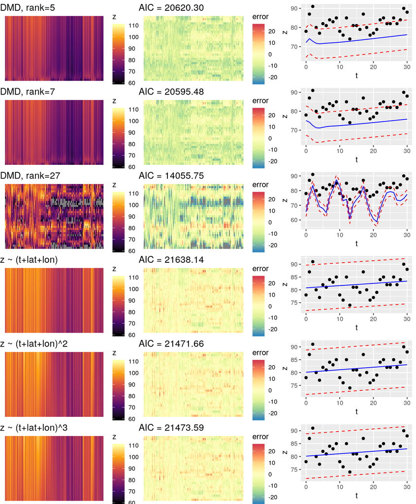

```r
q <- grid.arrange(grobs = p, ncol = 3)  #, theme(plot.margin=margin(250,10,10,10)))
```

```r
ggsave("prediction_comparison.png", q, dpi = 600, width = 12, height = 12, units = "in")
ggsave("prediction_comparison.pdf", q, dpi = 600, width = 12, height = 12, units = "in")
```

# More on Model Selection

Given the full DMD basis (i.e., rank 30), one can select the optimal combination of modes by an exhaustive search using AIC as the selection criterion. Here, the `leaps` package is applied following the example on Page 154 of Faraway. However, in that example AIC is not actually computed completely, so the model is reconstructed and AIC is computed using the built-in function.

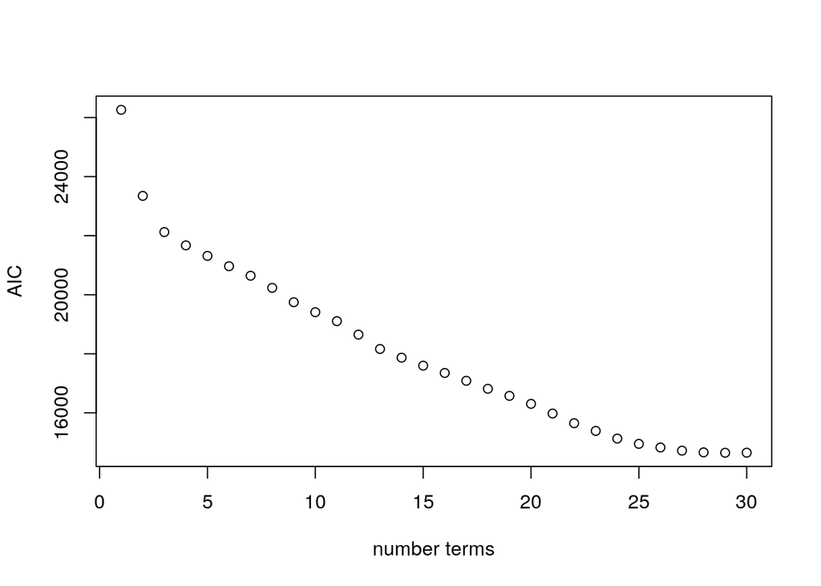

```r
library(leaps)
m <- lm_with_dmd(df, rank=-1, keep_pairs=2)
tmp_df <- df_add_dmd(subset(df, select=c(z, t)), m$dmd)
b <- regsubsets(z ~. - t, intercept=FALSE, data=tmp_df, nvmax=30)
rs <- summary(b)
num_models <- dim(rs$which)[1]
aic3 <- rep(0.0, num_models)
for (i in 1:num_models){
  aic3[i] <- AIC(lm(z~.-1, data=subset(tmp_df, select=c(z=TRUE, t=FALSE, rs$which[i,]))))
}
plot(aic3 ~ I(1:num_models), xlab="number terms", ylab="AIC")
```

For this particular set of basis functions, the model is improved with increasing numbers of terms. The overall trend follows that of the singular values computed previously for the snapshot matrix $\mathbf{Z}$. However, the basis functions kept for any number of terms was not in the order in which they appear in the DMD basis:

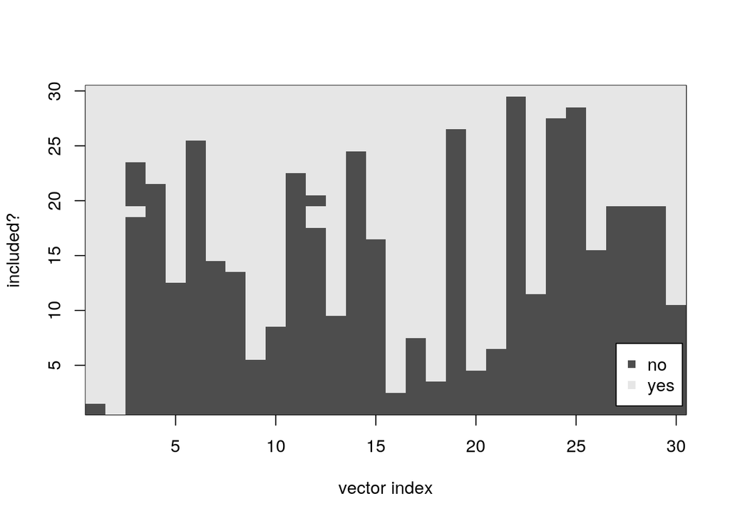

```r
image(1:30, 1:30, t(as.matrix(rs$which*1)), col=gray.colors(2), xlab="vector index", ylab="included?"); legend(x=27, y=7, legend = c("no", "yes"), pch=15, col=gray.colors(2))
```